# Modelos Temporales — Desapariciones en CDMX

Equipo

2026-05-17

```r
library(R2jags)
library(tidyverse)
library(sf)
library(corrplot)
```

# 1. Lectura y preparación de datos

```r
# LECTURA Y PREPARACION DE DATOS
data <- read_csv("../data/processed/data_final.csv")
```

```r
panel <- read.csv("../data/processed/data_final.csv")
names(panel)
```

```
##  [1] "MUNICIPIO"             "CVE_MUN"               "cve_mun_sesnsp"
##  [4] "anio"                  "mes"                   "n_desapariciones"
##  [7] "n_hombres"             "n_mujeres"             "n_desaparecidos"
## [10] "n_no_localizados"      "n_delitos_libertad"    "n_extorsion"
## [13] "n_feminicidios"        "n_homicidios"          "n_robos"
## [16] "n_violencia_familiar"  "fecha"                 "periodo_gobierno"
## [19] "post_2018"             "post_2024"             "pct_seguros_cdmx"
## [22] "pct_seguros_nacional"  "nom_alcaldia"          "pob_total"
## [25] "pob_femenina"          "pob_masculina"         "pob_18ymas"
## [28] "pob_15_64"             "tasa_desap_100k"       "tasa_desap_hombres"
## [31] "tasa_desap_mujeres"    "tasa_desap_anualizada" "ratio_mujer_hombre"
```

```r
# n_delitos_libertad significa "Delitos contra la libertad personal", que incluye secuestros, extorsiones, etc. Es una variable relevante para modelar desapariciones, ya que puede capturar el contexto de violencia y riesgo en el que ocurren las desapariciones.

# pct_seguros_cdmx es el porcentaje de personas que se sienten seguras en la Ciudad de México (fuente: ENVIPE/Monitor CDMX, interpolado mensualmente). Varía en el tiempo pero no entre alcaldías.
```

```r
# --------------------------------------------------------------
# Serie agregada CDMX mensual (Modelos 1,2 y 3)
# --------------------------------------------------------------
# Conteos: suma entre alcaldías
agg_counts <- aggregate(
  cbind(n_desapariciones, n_homicidios, n_robos, n_violencia_familiar,
        pct_seguros_cdmx, pob_total) ~ anio + mes,
  data = panel,
  FUN  = sum
)
# Indicadores binarios: mismo valor para todas las alcaldías en el mismo mes
agg_flags <- aggregate(
  cbind(post_2018, post_2024) ~ anio + mes,
  data = panel,
  FUN  = function(x) x[1]
)
agg <- merge(agg_counts, agg_flags, by = c("anio", "mes"))
agg <- agg[order(agg$anio, agg$mes), ]
agg
```

```
##     anio mes n_desapariciones n_homicidios n_robos n_violencia_familiar
## 4   2015   3               11           91    4817                  907
## 5   2015   4                4           51    2152                  471
## 6   2015   5                5           54    1802                  419
## 7   2015   6                5           68    3274                  683
## 8   2015   7                5           40    1880                  462
## 9   2015   8                3           26    1418                  222
## 10  2015   9                5           38    1457                  393
## 1   2015  10                3           44    1893                  511
## 2   2015  11                3           50    1466                  478
## 3   2015  12                4           31    1681                  463
## 11  2016   1                2           13    1216                  187
## 15  2016   2                1           21     881                  129
## 16  2016   3                3           53    1806                  529
## 17  2016   4                2            5     608                   69
```

[output cut: 237 more lines]

```r
# Estandarizar covariables continuas para evitar problemas numéricos
agg$homicidios_std  <- scale(agg$n_homicidios)[, 1]
agg$robos_std       <- scale(agg$n_robos)[, 1]
agg$violencia_std   <- scale(agg$n_violencia_familiar)[, 1]
agg$pct_seguros_std <- scale(agg$pct_seguros_cdmx)[, 1]

# Offset de población — log(pob_total_CDMX / 100k)
agg$offset <- log(agg$pob_total / 100000)

# Indice temporal (1 a n)
n   <- nrow(agg)
t   <- 1:n
```

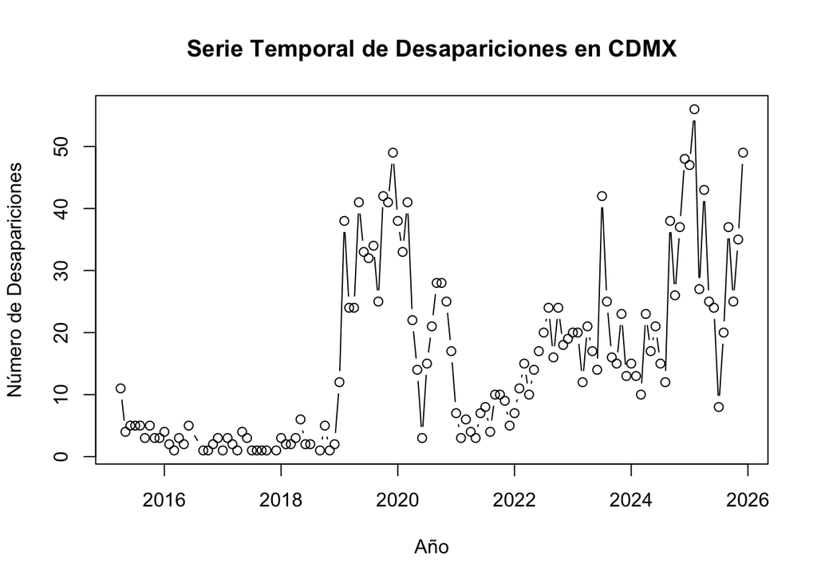

```r
plot(agg$anio + agg$mes / 12, agg$n_desapariciones, type = "b", xlab = "Año", ylab = "Número de Desapariciones", main = "Serie Temporal de Desapariciones en CDMX")
```

```r
# -------------------------------------------------------------------
# Panel alcaldia x mes - Modelo 3
# -------------------------------------------------------------------
panel_clean <- panel[!is.na(panel$pct_seguros_cdmx) & !is.na(panel$pob_total), ]
n_panel     <- nrow(panel_clean)
K           <- length(unique(panel_clean$CVE_MUN))   # 16 alcaldias

# Reindexar CVE_MUN a 1:16
panel_clean$alcaldia_idx <- as.integer(factor(panel_clean$CVE_MUN))

# Offset: log(poblacion / 100000) para modelar tasa por 100k
panel_clean$offset <- panel_clean$pob_total / 100000

panel_clean$homicidios_std  <- scale(panel_clean$n_homicidios)[, 1]
panel_clean$robos_std       <- scale(panel_clean$n_robos)[, 1]
panel_clean$violencia_std   <- scale(panel_clean$n_violencia_familiar)[, 1]
panel_clean$pct_seguros_std <- scale(panel_clean$pct_seguros_cdmx)[, 1]
```

# 2. Análisis exploratorio

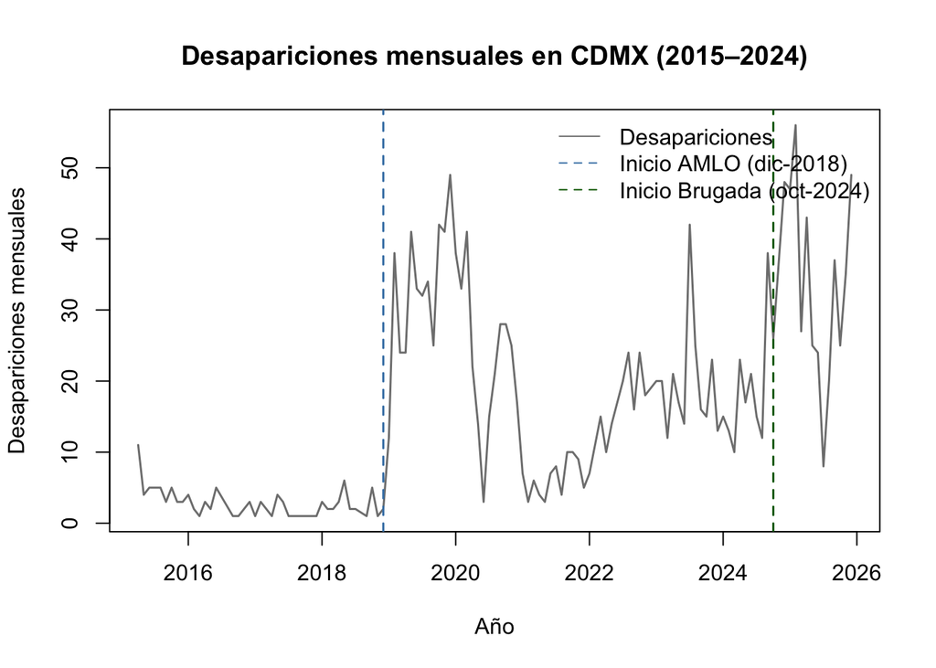

```r
# Serie temporal nacional con cambios de gobierno marcados
plot(agg$anio + agg$mes / 12, agg$n_desapariciones,
     type = "l", col = "grey50", lwd = 1.5,
     xlab = "Año", ylab = "Desapariciones mensuales",
     main = "Desapariciones mensuales en CDMX (2015–2024)")
abline(v = 2018 + 11/12, col = "steelblue", lty = 2, lwd = 1.5)
abline(v = 2024 + 9/12,  col = "darkgreen",  lty = 2, lwd = 1.5)
legend("topright",
       legend = c("Desapariciones",
                  "Inicio AMLO (dic-2018)",
                  "Inicio Brugada (oct-2024)"),
       col = c("grey50", "steelblue", "darkgreen"),
       lty = c(1, 2, 2), bty = "n")
```

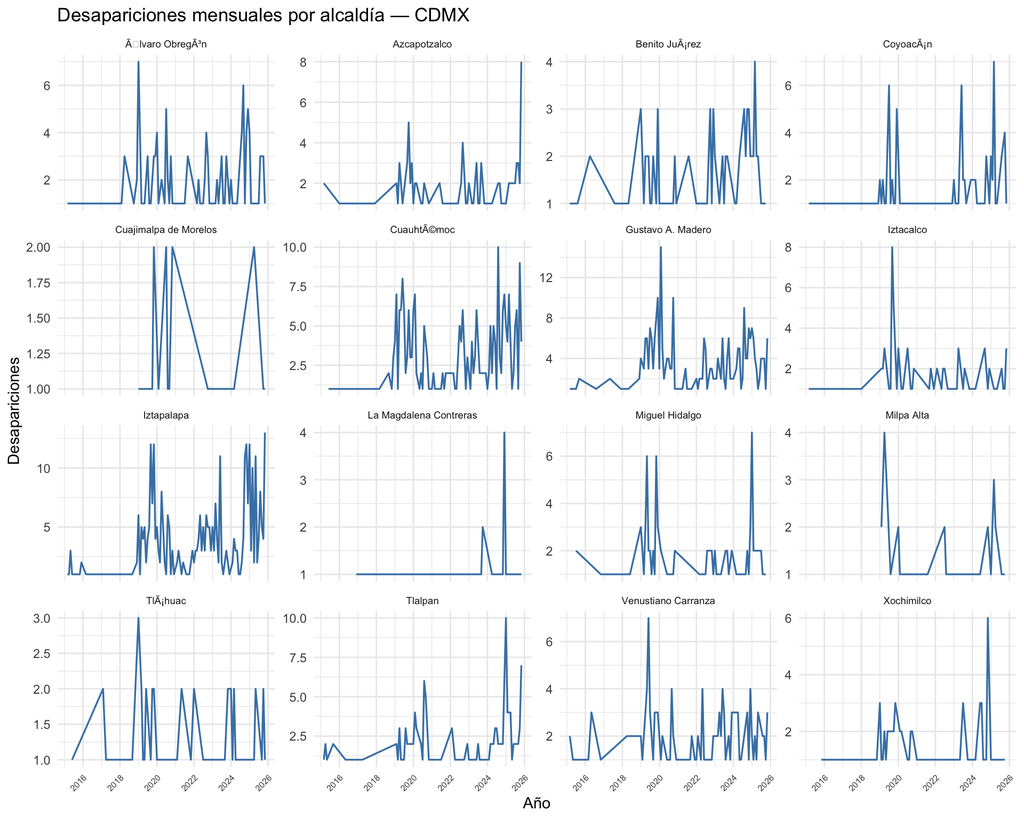

```r
# Serie por alcaldía — facetas para ver cada una claramente
panel_plot <- panel[!is.na(panel$pct_seguros_cdmx) &
                    !is.na(panel$pob_total), ]
panel_plot$fecha <- as.Date(panel_plot$fecha)
ggplot(panel_plot,
       aes(x = fecha, y = n_desapariciones)) +
  geom_line(color = "steelblue", linewidth = 0.6) +
  facet_wrap(~ nom_alcaldia, scales = "free_y", ncol = 4) +
  scale_x_date(date_breaks = "2 years", date_labels = "%Y") +
  labs(title = "Desapariciones mensuales por alcaldía — CDMX",
       x = "Año", y = "Desapariciones") +
  theme_minimal() +
  theme(axis.text.x = element_text(angle = 45, hjust = 1, size = 6),
        strip.text  = element_text(size = 7))
```

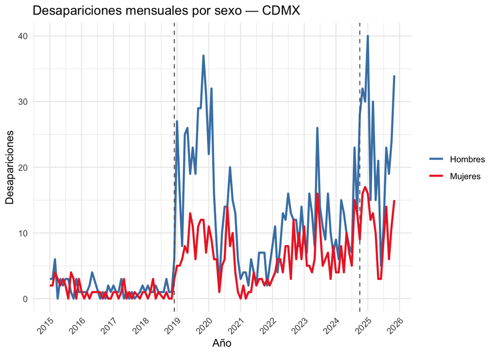

```r
# Desapariciones por sexo a lo largo del tiempo
panel %>%
  mutate(fecha_mes = as.Date(
    paste(anio, sprintf("%02d", mes), "01", sep = "-"))) %>%
  group_by(fecha_mes) %>%
  summarise(Hombres = sum(n_hombres, na.rm = TRUE),
            Mujeres = sum(n_mujeres, na.rm = TRUE),
            .groups = "drop") %>%
  pivot_longer(c(Hombres, Mujeres),
               names_to = "Sexo", values_to = "n") %>%
  ggplot(aes(x = fecha_mes, y = n, color = Sexo)) +
  geom_line(linewidth = 1) +
  scale_color_manual(values = c("Hombres" = "steelblue",
                                "Mujeres" = "firebrick2")) +
  scale_x_date(date_breaks = "1 year", date_labels = "%Y") +
  geom_vline(xintercept = as.Date("2018-12-01"),
             color = "grey40", lty = 2) +
  geom_vline(xintercept = as.Date("2024-10-01"),
             color = "grey40", lty = 2) +
  labs(title = "Desapariciones mensuales por sexo — CDMX",
       x = "Año", y = "Desapariciones", color = NULL) +
  theme_minimal() +
  theme(axis.text.x = element_text(angle = 45, hjust = 1))
```

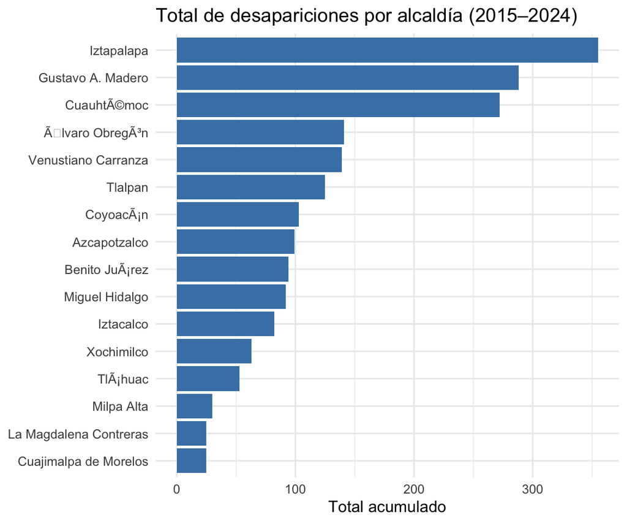

```r
# Total acumulado por alcaldía
panel %>%
  group_by(nom_alcaldia) %>%
  summarise(total = sum(n_desapariciones), .groups = "drop") %>%
  ggplot(aes(x = reorder(nom_alcaldia, total), y = total)) +
  geom_col(fill = "steelblue") +
  coord_flip() +
  labs(title = "Total de desapariciones por alcaldía (2015–2024)",
       x = NULL, y = "Total acumulado") +
  theme_minimal()
```

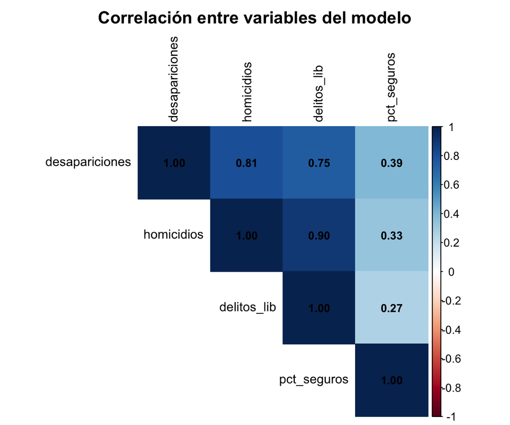

```r
# Correlación entre variables del modelo
vars_cor <- panel %>%
  mutate(fecha_mes = as.Date(
    paste(anio, sprintf("%02d", mes), "01", sep = "-"))) %>%
  group_by(fecha_mes) %>%
  summarise(desapariciones = sum(n_desapariciones),
            homicidios     = sum(n_homicidios),
            delitos_lib    = sum(n_delitos_libertad),
            pct_seguros    = mean(pct_seguros_cdmx, na.rm = TRUE),
            .groups = "drop") %>%
  select(-fecha_mes) %>%
  cor(use = "complete.obs")

corrplot(vars_cor,
         method      = "color",
         type        = "upper",
         addCoef.col = "black",
         tl.col      = "black",
         number.cex  = 0.8,
         tl.cex      = 0.9,
         title       = "Correlación entre variables del modelo",
         mar         = c(0, 0, 2, 0))
```

# 3. Modelo 1 — Poisson con dummies de cambio de gobierno

Modelo baseline con coeficientes **fijos**. Captura si en promedio hubo más desapariciones después del cambio de sexenio, sin incorporar dinámica.

```r
# =================================================================== #
# MODELO 1 — Poisson con dummies de cambio de gobierno
#            Serie agregada CDMX, variable dependiente: n_desapariciones
# =================================================================== #

data1 <- list("n"          = n,
              "y"          = as.integer(agg$n_desapariciones),
              "homicidios" = agg$homicidios_std,
              "robos"      = agg$robos_std,
              "violencia"  = agg$violencia_std,
              "pct_seguros"= agg$pct_seguros_std,
              "post2018"   = as.integer(agg$post_2018),
              "offset"     = agg$offset)

inits1 <- function() { list(beta = rep(0, 6), yf = rep(1, n)) }

pars1 <- c("beta", "mu", "yf")

mod1.sim <- jags(data1, inits1, pars1,
                 model.file = "../modelos/Mod1_Poisson_Breakpoint.txt",
                 n.iter   = 10000,
                 n.chains = 2,
                 n.burnin = 1000,
                 n.thin   = 2)
```

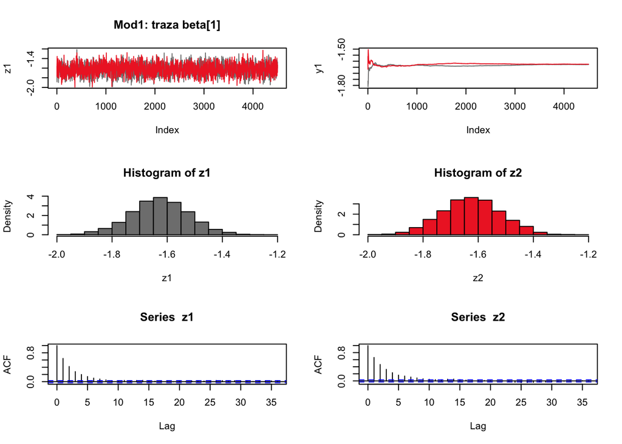

```r
# --- Diagnosticos Modelo 1 ---
#traceplot(mod1.sim)

out1.a   <- mod1.sim$BUGSoutput$sims.array
out1     <- mod1.sim$BUGSoutput$sims.list
out1.sum <- mod1.sim$BUGSoutput$summary

# Cadenas beta[1] (intercept)
z1 <- out1.a[, 1, 1]
z2 <- out1.a[, 2, 1]
par(mfrow = c(3, 2))
plot(z1, type = "l", col = "grey50", main = "Mod1: traza beta[1]")
lines(z2, col = "firebrick2")
y1 <- cumsum(z1) / (1:length(z1))
y2 <- cumsum(z2) / (1:length(z2))
plot(y1, type = "l", col = "grey50", ylim = range(y1, y2))
lines(y2, col = "firebrick2")
hist(z1, freq = FALSE, col = "grey50")
hist(z2, freq = FALSE, col = "firebrick2")
acf(z1); acf(z2)
```

```r
# Resumen de de estimadores betas
out1.sum.t <- out1.sum[grep("beta", rownames(out1.sum)), c(1, 3, 7)]
out1.sum.t <- cbind(out1.sum.t, apply(out1$beta, 2, prob))
dimnames(out1.sum.t)[[2]][4] <- "prob"
print("=== MODELO 1: Poisson Breakpoint ===")
```

```
## [1] "=== MODELO 1: Poisson Breakpoint ==="
```

```r
print(out1.sum.t)
```

```
##               mean         2.5%       97.5%        prob
## beta[1] -1.6259838 -1.833957991 -1.42179959 0.000000000
## beta[2]  0.1214953 -0.001312782  0.24413949 0.026333333
## beta[3]  0.1603933  0.045066751  0.27753187 0.003333333
## beta[4] -0.1367644 -0.290357479  0.02233538 0.044111111
## beta[5]  0.2679475  0.166184597  0.36844675 0.000000000
## beta[6]  0.2819725  0.025675505  0.53478608 0.014666667
```

```r
# DIC
out1.dic <- mod1.sim$BUGSoutput$DIC
print(c("DIC Mod1 =", out1.dic))
```

```
## [1] "DIC Mod1 ="       "707.803424616159"
```

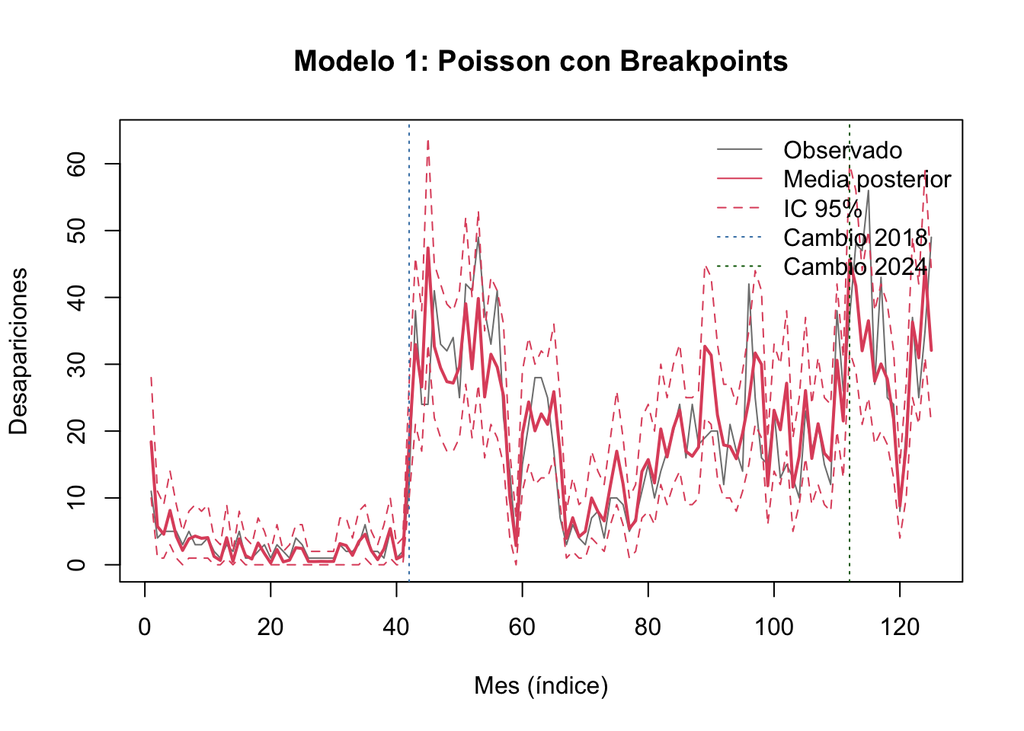

```r
# Predicciones vs observado
out1.yf <- out1.sum[grep("^yf", rownames(out1.sum)), ]
y       <- agg$n_desapariciones
ymin    <- min(y, out1.yf[, c(1, 3, 7)])
ymax    <- max(y, out1.yf[, c(1, 3, 7)])
par(mfrow = c(1, 1))
plot(t, y, type = "l", col = "grey50",
     ylim = c(ymin, ymax),
     xlab = "Mes (índice)", ylab = "Desapariciones",
     main = "Modelo 1: Poisson con Breakpoints")
lines(t, out1.yf[, 1], lwd = 2, col = 2)
lines(t, out1.yf[, 3], lty = 2, col = 2)
lines(t, out1.yf[, 7], lty = 2, col = 2)
abline(v = which(agg$post_2018 == 1)[1], col = "steelblue", lty = 3)
abline(v = which(agg$post_2024 == 1)[1], col = "darkgreen",  lty = 3)
legend("topright",
       legend = c("Observado", "Media posterior", "IC 95%",
                  "Cambio 2018", "Cambio 2024"),
       col = c("grey50", 2, 2, "steelblue", "darkgreen"),
       lty = c(1, 1, 2, 3, 3), bty = "n")
```

# 4. Modelo 2 — Binomial Negativa con covariables

```r
# =================================================================== #
# MODELO 2 — Binomial Negativa con covariables
#            Controla sobredispersion + percepcion + delitos libertad
# =================================================================== #

data2 <- list("n"          = n,
              "y"          = as.integer(agg$n_desapariciones),
              "homicidios" = agg$homicidios_std,
              "robos"      = agg$robos_std,
              "violencia"  = agg$violencia_std,
              "pct_seguros"= agg$pct_seguros_std,
              "post2018"   = as.integer(agg$post_2018),
              "offset"     = agg$offset)

inits2 <- function() { list(beta = rep(0, 6), r = 1, yf = rep(1, n)) }
pars2  <- c("beta", "r", "mu", "yf")

mod2.sim <- jags(data2, inits2, pars2,
                 model.file = "../modelos/Mod2_NegBin_Covariables.txt",
                 n.iter   = 12000,
                 n.chains = 2,
                 n.burnin = 2000,
                 n.thin   = 15)
```

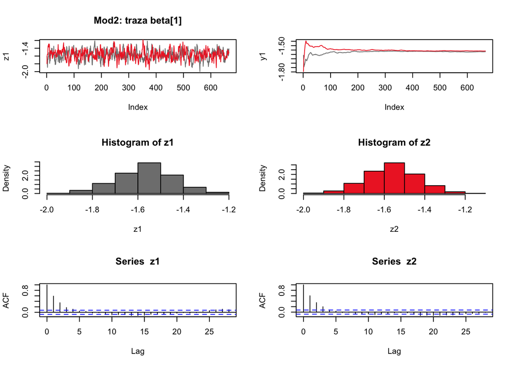

```r
# --- Diagnosticos Modelo 2 ---
out2.a   <- mod2.sim$BUGSoutput$sims.array
out2     <- mod2.sim$BUGSoutput$sims.list
out2.sum <- mod2.sim$BUGSoutput$summary

z1 <- out2.a[, 1, 1]
z2 <- out2.a[, 2, 1]
par(mfrow = c(3, 2))
plot(z1, type = "l", col = "grey50", main = "Mod2: traza beta[1]")
lines(z2, col = "firebrick2")
y1 <- cumsum(z1) / (1:length(z1))
y2 <- cumsum(z2) / (1:length(z2))
plot(y1, type = "l", col = "grey50", ylim = range(y1, y2))
lines(y2, col = "firebrick2")
hist(z1, freq = FALSE, col = "grey50")
hist(z2, freq = FALSE, col = "firebrick2")
acf(z1); acf(z2)
```

```r
# Resumen de betas
out2.sum.t <- out2.sum[grep("beta", rownames(out2.sum)), c(1, 3, 7)]
out2.sum.t <- cbind(out2.sum.t, apply(out2$beta, 2, prob))
dimnames(out2.sum.t)[[2]][4] <- "prob"
print("=== MODELO 2: Binomial Negativa con Covariables ===")
```

```
## [1] "=== MODELO 2: Binomial Negativa con Covariables ==="
```

```r
print(out2.sum.t)
```

```
##               mean         2.5%      97.5%       prob
## beta[1] -1.5649613 -1.815781681 -1.3230630 0.00000000
## beta[2]  0.1253656 -0.051845342  0.3182080 0.08333333
## beta[3]  0.1607321 -0.005544487  0.3307737 0.03228228
## beta[4] -0.1164059 -0.341860289  0.1026779 0.16291291
## beta[5]  0.2645382  0.121285270  0.4104670 0.00000000
## beta[6]  0.2023906 -0.122890449  0.5187775 0.09609610
```

```r
print(paste("r (sobredispersion) =", round(out2.sum["r", 1], 3)))
```

```
## [1] "r (sobredispersion) = 23.677"
```

```r
# DIC
out2.dic <- mod2.sim$BUGSoutput$DIC
print(c("DIC Mod2 =", out2.dic))
```

```
## [1] "DIC Mod2 ="       "680.816115630858"
```

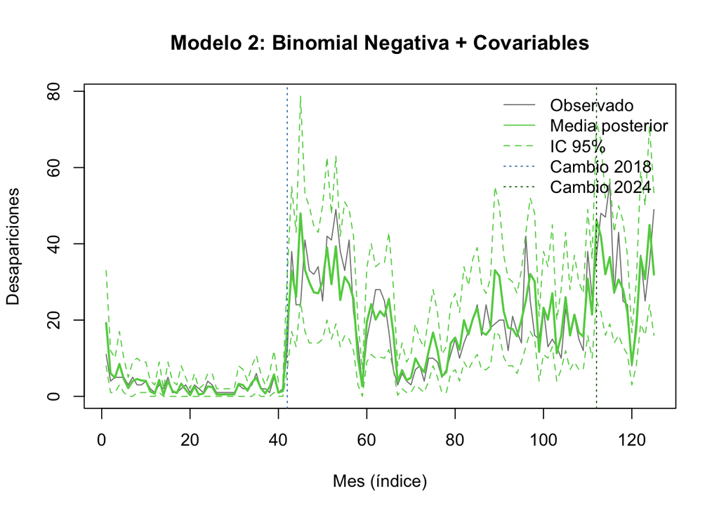

```r
# Predicciones
out2.yf <- out2.sum[grep("^yf", rownames(out2.sum)), ]
y       <- agg$n_desapariciones
ymin    <- min(y, out2.yf[, c(1, 3, 7)])
ymax    <- max(y, out2.yf[, c(1, 3, 7)])
par(mfrow = c(1, 1))
plot(t, y, type = "l", col = "grey50",
     ylim = c(ymin, ymax),
     xlab = "Mes (índice)", ylab = "Desapariciones",
     main = "Modelo 2: Binomial Negativa + Covariables")
lines(t, out2.yf[, 1], lwd = 2, col = 3)
lines(t, out2.yf[, 3], lty = 2, col = 3)
lines(t, out2.yf[, 7], lty = 2, col = 3)
abline(v = which(agg$post_2018 == 1)[1], col = "steelblue", lty = 3)
abline(v = which(agg$post_2024 == 1)[1], col = "darkgreen",  lty = 3)
legend("topright",
       legend = c("Observado", "Media posterior", "IC 95%",
                  "Cambio 2018", "Cambio 2024"),
       col = c("grey50", 3, 3, "steelblue", "darkgreen"),
       lty = c(1, 1, 2, 3, 3), bty = "n")
```

# 5. Modelo 3 — Poisson con efectos aleatorios por alcaldía

Usa el panel alcaldía × mes. Incorpora efectos aleatorios θₖ ~ N(0, τ_b) para capturar heterogeneidad entre alcaldías. Offset = población / 100k para modelar tasas comparables entre alcaldías de distinto tamaño.

```r
# =================================================================== #
# MODELO 3 — Poisson con efectos aleatorios por alcaldia (panel)
#            Variable dependiente: n_desapariciones, offset = pob/100k
# =================================================================== #

data3 <- list("n"          = n_panel,
              "K"          = K,
              "y"          = as.integer(panel_clean$n_desapariciones),
              "homicidios" = panel_clean$homicidios_std,
              "robos"      = panel_clean$robos_std,
              "violencia"  = panel_clean$violencia_std,
              "pct_seguros"= panel_clean$pct_seguros_std,
              "post2018"   = as.integer(panel_clean$post_2018),
              "alcaldia"   = as.integer(panel_clean$alcaldia_idx),
              "offset"     = panel_clean$offset)

inits3 <- function() {
  list(beta  = rep(0, 6),
       theta = rep(0, K),
       tau.b = 1,
       yf    = rep(1, n_panel))
}
pars3 <- c("beta", "theta", "tau.b", "sig.b", "yf")

mod3.sim <- jags(data3, inits3, pars3,
                 model.file = "../modelos/Mod3_Poisson_EfectosAleatorios.txt",
                 n.iter   = 10000,
                 n.chains = 2,
                 n.burnin = 1100,
                 n.thin   = 3)
```

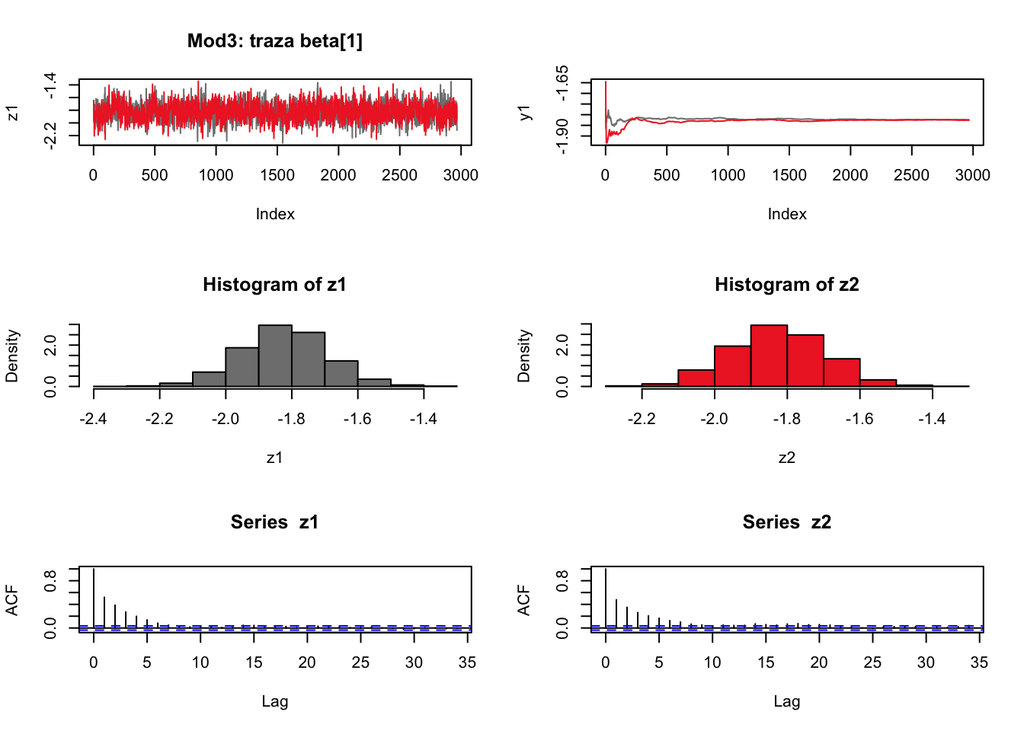

```r
# --- Diagnosticos Modelo 3 ---
out3.a   <- mod3.sim$BUGSoutput$sims.array
out3     <- mod3.sim$BUGSoutput$sims.list
out3.sum <- mod3.sim$BUGSoutput$summary

z1 <- out3.a[, 1, 1]
z2 <- out3.a[, 2, 1]
par(mfrow = c(3, 2))
plot(z1, type = "l", col = "grey50", main = "Mod3: traza beta[1]")
lines(z2, col = "firebrick2")
y1 <- cumsum(z1) / (1:length(z1))
y2 <- cumsum(z2) / (1:length(z2))
plot(y1, type = "l", col = "grey50", ylim = range(y1, y2))
lines(y2, col = "firebrick2")
hist(z1, freq = FALSE, col = "grey50")
hist(z2, freq = FALSE, col = "firebrick2")
acf(z1); acf(z2)
```

```r
# Resumen de betas (efectos fijos)
out3.sum.t <- out3.sum[grep("^beta", rownames(out3.sum)), c(1, 3, 7)]
out3.sum.t <- cbind(out3.sum.t, apply(out3$beta, 2, prob))
dimnames(out3.sum.t)[[2]][4] <- "prob"
print("=== MODELO 3: Poisson con Efectos Aleatorios por Alcaldía ===")
```

```
## [1] "=== MODELO 3: Poisson con Efectos Aleatorios por Alcaldía ==="
```

```r
print(out3.sum.t)
```

```
##                mean         2.5%       97.5%        prob
## beta[1] -1.82480968 -2.077581956 -1.56734948 0.000000000
## beta[2]  0.08286643  0.002320988  0.16283299 0.021746460
## beta[3] -0.06770612 -0.161863245  0.02747601 0.082097100
## beta[4] -0.13987998 -0.243821213 -0.03129565 0.006574511
## beta[5] -0.01507411 -0.082174141  0.05051372 0.330748483
## beta[6]  0.89774633  0.697250067  1.10266903 0.000000000
```

```r
# DIC
out3.dic <- mod3.sim$BUGSoutput$DIC
print(c("DIC Mod3 =", out3.dic))
```

```
## [1] "DIC Mod3 ="       "2975.52323065945"
```

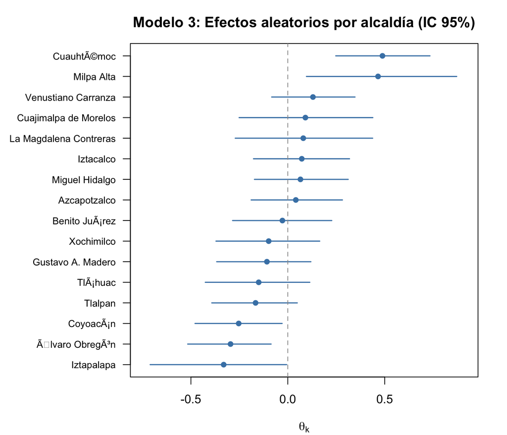

```r
# Efectos aleatorios por alcaldia — caterpillar plot horizontal
out3.theta <- out3.sum[grep("^theta", rownames(out3.sum)), c(1, 3, 7)]

# Mapeo índice → nombre de alcaldía
mapeo   <- unique(panel_clean[, c("alcaldia_idx", "nom_alcaldia")])
mapeo   <- mapeo[order(mapeo$alcaldia_idx), ]
nombres <- mapeo$nom_alcaldia

# Ordenar de menor a mayor efecto medio
ord       <- order(out3.theta[, 1])
theta_ord <- out3.theta[ord, ]
nom_ord   <- nombres[ord]

par(mfrow = c(1, 1), mar = c(4, 9, 3, 2))
plot(theta_ord[, 1], 1:K,
     xlim = range(theta_ord) * 1.05,
     yaxt = "n",
     xlab = expression(theta[k]),
     ylab = "",
     main = "Modelo 3: Efectos aleatorios por alcaldía (IC 95%)",
     pch = 19, col = "steelblue", cex = 0.9)
segments(theta_ord[, 2], 1:K, theta_ord[, 3], 1:K, col = "steelblue", lwd = 1.5)
axis(2, at = 1:K, labels = nom_ord, las = 1, cex.axis = 0.8)
abline(v = 0, col = "grey60", lty = 2)
```

Interpretación

El Modelo 3 incorpora efectos aleatorios θₖ por alcaldía para capturar heterogeneidad espacial no explicada por las covariables. Los efectos estimados muestran que, tras controlar por homicidios, robos, violencia familiar y percepción de seguridad, la mayoría de las 16 alcaldías presentan efectos cercanos a cero con intervalos de credibilidad al 95% que incluyen el cero, lo que sugiere que las covariables incluidas explican adecuadamente la variación entre alcaldías.